# 📚 Chapter 10: Deep Learning

ISLR2 Book - Python Implementation with PyTorch

Interactive Notebook with Collapsible Code Sections

Markdown

# Chapter 10

Code

**In [2]** ▶

```
import sys
from pathlib import Path
from IPython.paths import get_ipython_dir
import subprocess

subprocess.check_call([sys.executable, "-m", "pip", "install", "torchinfo"])

startup_file = Path(get_ipython_dir()) / "profile_default" / "startup" / "00-first.py"
startup_file.parent.mkdir(parents=True, exist_ok=True)
line = "import torchinfo\n"
if startup_file.exists():
    content = startup_file.read_text(encoding="utf-8")
    if "import torchinfo" not in content:
        startup_file.write_text(content + line, encoding="utf-8")
else:
    startup_file.write_text(line, encoding="utf-8")
```

Code

**In [3]** ▶

```
%pip install torchinfo
```

**Output:** Requirement already satisfied: torchinfo in c:\users\pmls\miniconda3\envs\dl\lib\site-packages (1.8.0) Note: you may need to restart the kernel to use updated packages.

Code

**In [4]** ▶

```
%pip install torchvision
```

Code

**In [5]** ▶

```
import numpy as np, pandas as pd
import matplotlib.pyplot as plt
from matplotlib.pyplot import subplots
from sklearn.linear_model import \
     (LinearRegression,
      LogisticRegression,
      Lasso)
from sklearn.preprocessing import StandardScaler
from sklearn.model_selection import KFold
from sklearn.pipeline import Pipeline
from ISLP import load_data
from ISLP.models import (ModelSpec as MS, summarize)
from sklearn.model_selection import \
     (train_test_split,
      GridSearchCV)

import torch
from torch import nn
from torch.optim import (RMSprop, Adam)
from torch.utils.data import TensorDataset

from torchmetrics import (MeanAbsoluteError,R2Score)
from torchinfo import summary
from torchvision.io import read_image

from pytorch_lightning import Trainer
from pytorch_lightning.loggers import CSVLogger
from pytorch_lightning import seed_everything

seed_everything(0, workers=True)
torch.use_deterministic_algorithms(True, warn_only=True)

from torchvision.datasets import MNIST, CIFAR100
from torchvision.models import (resnet50,
                                ResNet50_Weights)
from torchvision.transforms import (Resize,
                                    Normalize,
                                    CenterCrop,
                                    ToTensor)

from ISLP.torch import (SimpleDataModule,
                        SimpleModule,
                        ErrorTracker,
                        rec_num_workers)
from ISLP.torch.imdb import (load_lookup,
                             load_tensor,
                             load_sparse,
                             load_sequential)
import torch.optim as optim
import statsmodels.api as sm
from glob import glob
import json
```

Code

**In [20]** ▶

[output not shown]

Markdown

## Exercise 6

Code

**In [6]** ▶

```
def R(beta):
  return np.sin(beta)+beta/10
```

Markdown

### (a)

Code

**In [22]** ▶

```
fig,ax=subplots(figsize=(10,10))
beta=np.linspace(-6, 6, 1000)
y=R(beta)
ax.plot(beta,y)
ax.set_xlabel(r'$\beta$')
ax.set_ylabel('R');
```

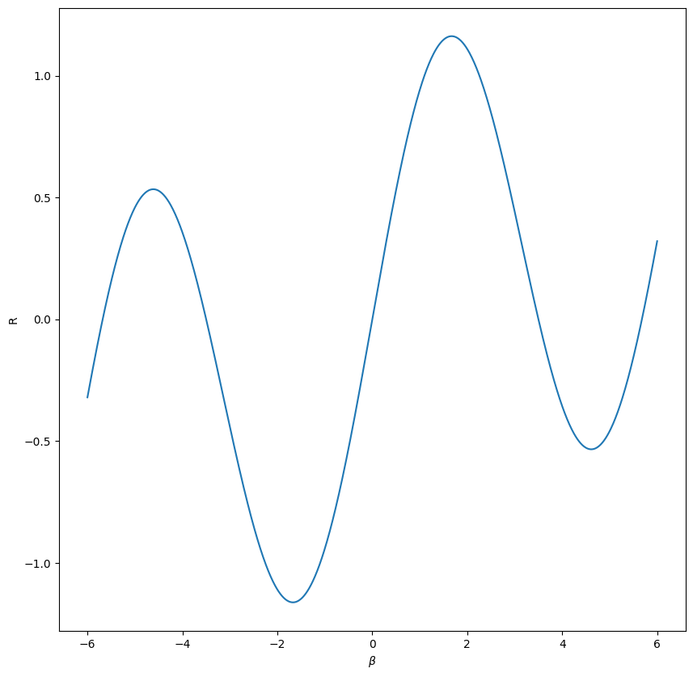

Markdown

### (b)

Markdown

Derivative of the function $R(\beta)$ is $R^{'}(\beta)=cos(\beta)+1/10$

Markdown

### (c)

Code

**In [7]** ▶

```
def deR(beta):
  return np.cos(beta)+1/10
```

Code

**In [8]** ▶

```
#Let's define the function gradient_descent which returns a tuple containing both the extermal point and the point at which it occurs
def gradient_descent(init_point,objective=R, derivative=deR, n_iter=30, step_size=0.1):
  betas, scores = [], []
  for i in range(n_iter):
    gradient = derivative(init_point)
    init_point = init_point - step_size * gradient
    solution_eval = objective(init_point)
    betas.append(init_point)
    scores.append(solution_eval)
  return [betas, scores]
```

Code

**In [9]** ▶

```
solutions, scores = gradient_descent(init_point=2.3,n_iter=50)
```

Code

**In [10]** ▶

```
fig,ax=subplots(figsize=(15,15))
beta=np.linspace(2, 6, 1000)
y=R(beta)
ax.plot(beta,y)
ax.set_xlabel(r'$\beta$')
ax.set_ylabel('R')
ax.plot(solutions,scores,'.-', color='red');
```

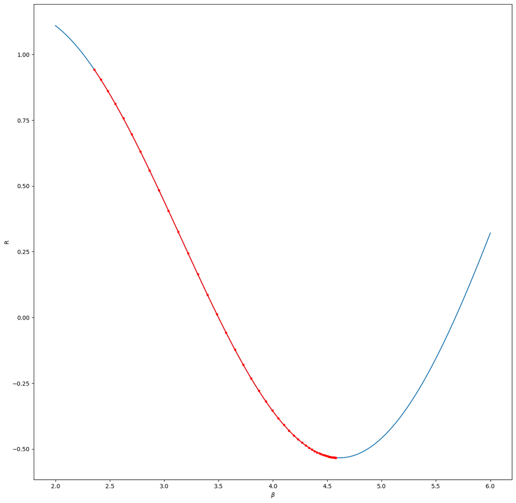

Markdown

### (d)

Code

**In [9]** ▶

```
solutions, scores = gradient_descent(init_point=1.4,n_iter=70)
```

Code

**In [10]** ▶

```
fig,ax=subplots(figsize=(15,15))
beta=np.linspace(-6, 6, 1000)
y=R(beta)
ax.plot(beta,y)
ax.set_xlabel(r'$\beta$')
ax.set_ylabel('R')
ax.plot(solutions,scores,'.-', color='red');
```

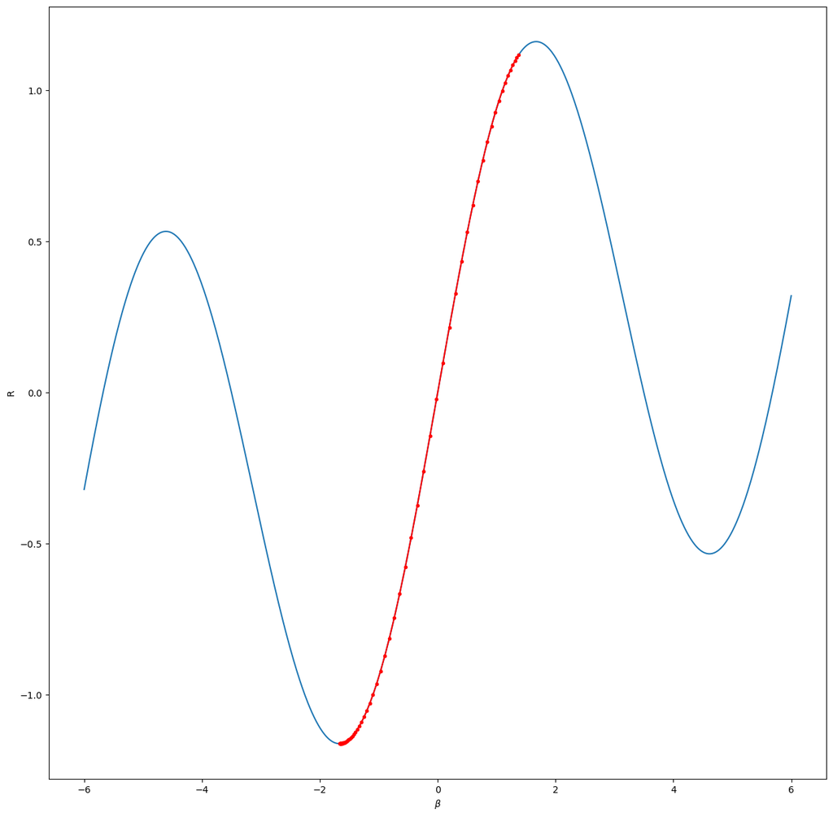

Markdown

## Exercise 7

Code

**In [11]** ▶

```
Default=load_data("Default")
```

Code

**In [12]** ▶

```
Default.head()
```

default student balance income 0 No No 729.526495 44361.625074 1 No Yes 817.180407 12106.134700 2 No No 1073.549164 31767.138947 3 No No 529.250605 35704.493935 4 No No 785.655883 38463.495879

Code

**In [13]** ▶

```
Default.info()
```

**Output:** RangeIndex: 10000 entries, 0 to 9999 Data columns (total 4 columns): # Column Non-Null Count Dtype --- ------ -------------- ----- 0 default 10000 non-null category 1 student 10000 non-null category 2 balance 10000 non-null float64 3 income 10000 non-null float64 dtypes: category(2), float64(2) memory usage: 176.2 KB

Code

**In [14]** ▶

```
Default['default']=np.where(Default['default']=='Yes',int(1),int(0))
Default['student']=np.where(Default['student']=='Yes',int(1),int(0))
```

Code

**In [15]** ▶

```
model=MS(Default.columns.drop('default'),intercept=False)
X=model.fit_transform(Default).to_numpy()
Y=Default['default'].to_numpy()
```

Code

**In [16]** ▶

```
(X_train,X_test,Y_train,Y_test)=train_test_split(X,Y,test_size=1/3,random_state=10)
```

Code

**In [17]** ▶

```
class DefaultModel(nn.Module):
  def __init__(self,input_size):
    super(DefaultModel,self).__init__()
    self.flatten=nn.Flatten()
    self.sequential=nn.Sequential(
        nn.Linear(input_size,10),
        nn.ReLU(),
        nn.Dropout(0.4),
        nn.Linear(10,1),
        nn.Sigmoid())#use Sigmoid function because the response is qualitative with only classes
  def forward(self,x):
    x=self.flatten(x)
    return torch.flatten(self.sequential(x))
```

Code

**In [18]** ▶

```
Default_Model=DefaultModel(X.shape[1])
```

Code

**In [19]** ▶

```
#Form the tensor dataset for the training set
X_train_t=torch.tensor(X_train.astype(np.float32))
Y_train_t=torch.tensor(Y_train.astype(np.float32))
Default_train=TensorDataset(X_train_t,Y_train_t)
```

Code

**In [20]** ▶

```
Default_Model(X_train_t)
```

tensor([1., 0., 0., ..., 0., 0., 0.], grad_fn=)

Code

**In [21]** ▶

```
#Form the tensor dataset for the test set
X_test_t=torch.tensor(X_test.astype(np.float32))
Y_test_t=torch.tensor(Y_test.astype(np.float32))
Default_test=TensorDataset(X_test_t,Y_test_t)
```

Code

**In [22]** ▶

```
#Define the number of processes to use when loading the data in the network
max_num_workers=rec_num_workers()
```

Code

**In [23]** ▶

```
Default_dm=SimpleDataModule(Default_train,Default_test,batch_size=32,num_workers=min(4,max_num_workers),validation=Default_test)
```

Code

**In [24]** ▶

```
# We use the cross-entropy as a performance metric of the model
Default_module=SimpleModule.classification(Default_Model,num_classes=2)
```

Code

**In [25]** ▶

```
#Form a results ledger
Default_logger=CSVLogger('logs',name='default')
```

Code

**In [26]** ▶

```
Default_trainer=Trainer(deterministic=True,
                        max_epochs=50,
                        log_every_n_steps=208,
                        logger=Default_logger,
                        callbacks=[ErrorTracker()])
Default_trainer.fit(Default_module,datamodule=Default_dm)
```

**Output:** 💡 Tip: For seamless cloud uploads and versioning, try installing [litmodels](https://pypi.org/project/litmodels/) to enable LitModelCheckpoint, which syncs automatically with the Lightning model registry. GPU available: False, used: False TPU available: False, using: 0 TPU cores

```
┏━━━┳━━━━━━━┳━━━━━━━━━━━━━━━━━━┳━━━━━━━━┳━━━━━━━┳━━━━━━━┓
┃   ┃ Name  ┃ Type             ┃ Params ┃ Mode  ┃ FLOPs ┃
┡━━━╇━━━━━━━╇━━━━━━━━━━━━━━━━━━╇━━━━━━━━╇━━━━━━━╇━━━━━━━┩
│ 0 │ model │ DefaultModel     │     51 │ train │     0 │
│ 1 │ loss  │ CrossEntropyLoss │      0 │ train │     0 │
└───┴───────┴──────────────────┴────────┴───────┴───────┘
```

```
Trainable params: 51
Non-trainable params: 0
Total params: 51
Total estimated model params size (MB): 0
Modules in train mode: 9
Modules in eval mode: 0
Total FLOPs: 0
```

**Output:** `Trainer.fit` stopped: `max_epochs=50` reached.

Code

**In [27]** ▶

```
Default_trainer.test(Default_module , datamodule=Default_dm)
```

```
┏━━━━━━━━━━━━━━━━━━━━━━━━━━━┳━━━━━━━━━━━━━━━━━━━━━━━━━━━┓
┃        Test metric        ┃       DataLoader 0        ┃
┡━━━━━━━━━━━━━━━━━━━━━━━━━━━╇━━━━━━━━━━━━━━━━━━━━━━━━━━━┩
│       test_accuracy       │    0.9628074169158936     │
│         test_loss         │    1005.8790283203125     │
└───────────────────────────┴───────────────────────────┘
```

[{'test_loss': 1005.8790283203125, 'test_accuracy': 0.9628074169158936}]

Code

**In [28]** ▶

```
# Fit logistic regression
glm = sm.GLM(Y_train,X_train,family=sm.families.Binomial())
results = glm.fit()
summarize(results)
```

coef std err z P>|z| x1 -3.6731 0.187000 -19.600 0.0 x2 0.0027 0.000000 17.481 0.0 x3 -0.0002 0.000006 -27.305 0.0

Code

**In [29]** ▶

```
probs = results.predict(X_test)
```

Code

**In [30]** ▶

```
labels=np.array([0]*X_test.shape[0])
labels[probs>0.5]=1#Remember 1 means that default has occured
```

Code

**In [32]** ▶

```
import ISLP
```

Code

**In [33]** ▶

```
C=ISLP.confusion_table(labels,Y_test)
```

Code

**Cell 36** ▶

```
C
```

Truth 0 1 Predicted 0 3195 118 1 15 6

Code

**In [34]** ▶

```
(3195+6)/Y_test.shape[0]
```

0.9601079784043192

Markdown

The sequential neural network and logistic regression models have approximately the same test performance.

Markdown

## Exercise 8

Markdown

Code

**In [66]** ▶

```
# Step 1: Download or create imagenet_class_index.json
import urllib.request
import os
import json

image_folder = r"d:\ISLR2 book Exercise with python\deep_learning with_r"
json_file = os.path.join(image_folder, 'imagenet_class_index.json')

if not os.path.exists(json_file):
    try:
        print("Downloading imagenet_class_index.json...")
        urllib.request.urlretrieve('https://s3.amazonaws.com/deep-learning-models/imagenet-class-index.json', json_file)
        print(f"Downloaded to {json_file}")
    except:
        print("Could not download - will create sample labels")
else:
    print(f"imagenet_class_index.json already exists at {json_file}")
```

**Output:** Downloading imagenet_class_index.json... Could not download - will create sample labels

Code

**In [67]** ▶

```
# Step 2: Create sample image tensors for demonstration
# (Or download from URLs if internet is available)
print("Creating sample image tensors for demonstration...")

# Create 8 sample images with random features (ResNet50 expects 3x224x224)
num_images = 8
sample_images = torch.randn(num_images, 3, 224, 224)

# Normalize to valid range [0, 1]
sample_images = (sample_images - sample_images.min()) / (sample_images.max() - sample_images.min())

imgs = sample_images
imgfiles = [f'sample_image_{i}.jpg' for i in range(num_images)]

print(f"Created {len(imgfiles)} sample images")
print(f"Image tensor shape: {imgs.size()}")
```

**Output:** Creating sample image tensors for demonstration... Created 8 sample images Image tensor shape: torch.Size([8, 3, 224, 224])

Code

**In [68]** ▶

```
# Step 3: Verify images are ready for ResNet50
if len(imgfiles) > 0:
    print(f"\nImages ready for ResNet50")
    print(f"Total images: {len(imgfiles)}")
    print(f"Image tensor shape: {imgs.size()}")
    print(f"Data type: {imgs.dtype}")
    print(f"Value range: [{imgs.min():.3f}, {imgs.max():.3f}]")
else:
    print("No images found!")
```

**Output:** Images ready for ResNet50 Total images: 8 Image tensor shape: torch.Size([8, 3, 224, 224]) Data type: torch.float32 Value range: [0.000, 1.000]

Code

**In [69]** ▶

```
# Step 4: Load ResNet50 and make predictions
resnet_model = resnet50(weights=ResNet50_Weights.DEFAULT)
resnet_model.eval()

print("\nRunning ResNet50 inference...")
with torch.no_grad():
    img_preds = resnet_model(imgs)

# Convert logits to probabilities
img_probs = torch.nn.functional.softmax(img_preds, dim=1).numpy()
print("Inference completed!")
```

**Output:** Running ResNet50 inference... Inference completed!

Code

**Cell 42** ▶

[output not shown]

Code

**In [45]** ▶

```
NYSE=load_data('NYSE')
cols=['DJ_return','log_volume','log_volatility']
X=pd.DataFrame(StandardScaler(with_mean=True,with_std=True).fit_transform(NYSE[cols]),columns=NYSE[cols].columns,index=NYSE.index)
```

Code

**In [46]** ▶

```
NYSE
```

day_of_week DJ_return log_volume log_volatility train date 1962-12-03 mon -0.004461 0.032573 -13.127403 True 1962-12-04 tues 0.007813 0.346202 -11.749305 True 1962-12-05 wed 0.003845 0.525306 -11.665609 True 1962-12-06 thur -0.003462 0.210182 -11.626772 True 1962-12-07 fri 0.000568 0.044187 -11.728130 True ... ... ... ... ... ... 1986-12-24 wed 0.006514 -0.236104 -9.807366 False 1986-12-26 fri 0.001825 -1.322425 -9.906025 False 1986-12-29 mon -0.009515 -0.371237 -9.827660 False 1986-12-30 tues -0.001837 -0.385638 -9.926091 False 1986-12-31 wed -0.006655 -0.264986 -9.935527 False [6051 rows x 5 columns]

Code

**In [47]** ▶

```
#Set up the number of lags
L=5
for lag in range(1,L+1):
  for col in cols:
    newcol=np.zeros(X.shape[0])*np.nan
    newcol[lag:]=X[col].values[:-lag]
    X.insert(len(X.columns),'{0}_{1}'.format(col,lag),newcol)
X.insert(len(X.columns),'train',NYSE['train'])
X=X.dropna()
```

Code

**In [48]** ▶

```
Y,train=X['log_volume'],X['train']
X=X.drop(columns=['train']+cols)
```

Code

**In [49]** ▶

```
M=LinearRegression()
M.fit(X[train],Y[train])
M.score(X[~train],Y[~train])
```

0.41289129385625223

Code

**In [50]** ▶

```
#Refit the model with a 12-level factor representing the month
month=[]
for i in range(len(NYSE.index)):
  month.append(NYSE.index[i][5:7])
Month=pd.DataFrame(month,index=NYSE.index)
```

Code

**In [51]** ▶

```
X_month=pd.merge(X,pd.get_dummies(Month),on='date')
M.fit(X_month[train], Y[train])
M.score(X_month[~train], Y[~train])
```

0.4167123048568927

Markdown

The integration of the month only improves the $R^2$ with $0.4$%.

Markdown

## Exercise 10

Code

**In [52]** ▶

```
#Flatten the RNN without the feature set X_day and exclude hidden layers to reconstruct AR with lag=5
NYSE=load_data('NYSE')
cols=['DJ_return','log_volume','log_volatility']
X=pd.DataFrame(StandardScaler(with_mean=True,with_std=True).fit_transform(NYSE[cols]),columns=NYSE[cols].columns,index=NYSE.index)
```

Code

**In [53]** ▶

```
#Set up the number of lags
L=5
for lag in range(1,L+1):
  for col in cols:
    newcol=np.zeros(X.shape[0])*np.nan
    newcol[lag:]=X[col].values[:-lag]
    X.insert(len(X.columns),'{0}_{1}'.format(col,lag),newcol)
X.insert(len(X.columns),'train',NYSE['train'])
X=X.dropna()
```

Code

**In [54]** ▶

```
Y,train=X['log_volume'],X['train']
X=X.drop(columns=['train']+cols)
```

Code

**In [55]** ▶

```
#Reorder columns and reshape data
ordered_cols = []
for lag in range(5,0,-1):
  for col in cols:
    ordered_cols.append('{0}_{1}'.format(col , lag))
X = X.reindex(columns=ordered_cols)
X_rnn = X.to_numpy().reshape((-1,5,3))
X_rnn.shape
```

(6046, 5, 3)

Code

**In [56]** ▶

```
#Form the training and test data set
datasets = []
for mask in [train , ~train]:
  X_rnn_t = torch.tensor(X_rnn[mask].astype(np.float32))
  Y_t = torch.tensor(Y[mask].astype(np.float32))
  datasets.append(TensorDataset(X_rnn_t , Y_t))
nyse_train , nyse_test = datasets
```

Code

**In [59]** ▶

```
#Create data module
max_num_workers=rec_num_workers()
nyse_dm = SimpleDataModule(nyse_train,nyse_test,num_workers=min(4, max_num_workers),validation=nyse_test,batch_size =64)
```

Code

**In [60]** ▶

```
class LinearARModel(nn.Module):
  def __init__(self):
    super(LinearARModel , self).__init__()
    self._forward = nn.Sequential(nn.Flatten(),
    nn.Linear(15,20),
    nn.Dropout (0.5),
    nn.Linear(20, 1))
  def forward(self , x):
    return torch.flatten(self._forward(x))
```

Code

**In [62]** ▶

```
l_model=LinearARModel()
l_optimizer = RMSprop(l_model.parameters(),lr=0.001)
l_module = SimpleModule.regression(l_model ,optimizer=l_optimizer ,metrics={'r2':R2Score ()})
```

Code

**In [63]** ▶

```
l_trainer = Trainer(deterministic=True ,max_epochs=20,callbacks=[ErrorTracker()])
l_trainer.fit(l_module , datamodule=nyse_dm)
l_trainer.test(l_module , datamodule=nyse_dm)
```

```
┏━━━┳━━━━━━━┳━━━━━━━━━━━━━━━┳━━━━━━━━┳━━━━━━━┳━━━━━━━┓
┃   ┃ Name  ┃ Type          ┃ Params ┃ Mode  ┃ FLOPs ┃
┡━━━╇━━━━━━━╇━━━━━━━━━━━━━━━╇━━━━━━━━╇━━━━━━━╇━━━━━━━┩
│ 0 │ model │ LinearARModel │    341 │ train │     0 │
│ 1 │ loss  │ MSELoss       │      0 │ train │     0 │
└───┴───────┴───────────────┴────────┴───────┴───────┘
```

```
Trainable params: 341
Non-trainable params: 0
Total params: 341
Total estimated model params size (MB): 0
Modules in train mode: 7
Modules in eval mode: 0
Total FLOPs: 0
```

**Output:** `Trainer.fit` stopped: `max_epochs=20` reached.

```
┏━━━━━━━━━━━━━━━━━━━━━━━━━━━┳━━━━━━━━━━━━━━━━━━━━━━━━━━━┓
┃        Test metric        ┃       DataLoader 0        ┃
┡━━━━━━━━━━━━━━━━━━━━━━━━━━━╇━━━━━━━━━━━━━━━━━━━━━━━━━━━┩
│         test_loss         │    0.6271775364875793     │
│          test_r2          │    0.4047778844833374     │
└───────────────────────────┴───────────────────────────┘
```

[{'test_loss': 0.6271775364875793, 'test_r2': 0.4047778844833374}]

Markdown

Markdown

## Exercise 11

Code

**In [64]** ▶

```
NYSE=load_data('NYSE')
cols=['DJ_return','log_volume','log_volatility']
X=pd.DataFrame(StandardScaler(with_mean=True,with_std=True).fit_transform(NYSE[cols]),columns=NYSE[cols].columns,index=NYSE.index)
```

Code

**In [68]** ▶

```
NYSE=load_data('NYSE')
cols=['DJ_return','log_volume','log_volatility']
X=pd.DataFrame(StandardScaler(with_mean=True,with_std=True).fit_transform(NYSE[cols]),columns=NYSE[cols].columns,index=NYSE.index)

# Set up the number of lags
L=5
for lag in range(1,L+1):
  for col in cols:
    newcol=np.zeros(X.shape[0])*np.nan
    newcol[lag:]=X[col].values[:-lag]
    X.insert(len(X.columns),'{0}_{1}'.format(col,lag),newcol)
X.insert(len(X.columns),'train',NYSE['train'])
X=X.dropna()

Y,train=X['log_volume'],X['train']
X=X.drop(columns=['train']+cols)
```

Code

**In [70]** ▶

```
ordered_cols = []
for lag in range(5,0,-1):
  for col in cols:
    ordered_cols.append('{0}_{1}'.format(col , lag))
X = X.reindex(columns=ordered_cols)
X_rnn = X.to_numpy().reshape((-1,5,3))
X_rnn.shape
```

(6046, 5, 3)

Code

**In [71]** ▶

```
datasets = []
for mask in [train , ~train]:
  X_rnn_t = torch.tensor(X_rnn[mask].astype(np.float32))
  Y_t = torch.tensor(Y[mask].astype(np.float32))
  datasets.append(TensorDataset(X_rnn_t , Y_t))
nyse_train , nyse_test = datasets
```

Code

**In [72]** ▶

```
max_num_workers=rec_num_workers()
nyse_dm = SimpleDataModule(nyse_train,nyse_test,num_workers=min(4, max_num_workers),validation=nyse_test,batch_size =64)
```

Code

**In [73]** ▶

```
class NonLinearARModel(nn.Module):
  def __init__(self):
    super(NonLinearARModel , self).__init__()
    self._forward = nn.Sequential(nn.Flatten(),
    nn.Linear(15,32),
    nn.ReLU(),
    nn.Dropout (0.5),
    nn.Linear(32, 1))
  def forward(self , x):
    return torch.flatten(self._forward(x))
```

Code

**In [74]** ▶

```
nl_model=NonLinearARModel()
nl_optimizer = RMSprop(nl_model.parameters(),lr=0.001)
nl_module = SimpleModule.regression(nl_model ,optimizer=nl_optimizer ,metrics={'r2':R2Score ()})
```

Code

**In [76]** ▶

```
nl_trainer = Trainer(deterministic=True ,max_epochs=20,callbacks=[ErrorTracker()])
nl_trainer.fit(nl_module , datamodule=nyse_dm)
nl_trainer.test(nl_module , datamodule=nyse_dm)
```

**Output:** 💡 Tip: For seamless cloud uploads and versioning, try installing [litmodels](https://pypi.org/project/litmodels/) to enable LitModelCheckpoint, which syncs automatically with the Lightning model registry. GPU available: False, used: False TPU available: False, using: 0 TPU cores

```
┏━━━┳━━━━━━━┳━━━━━━━━━━━━━━━━━━┳━━━━━━━━┳━━━━━━━┳━━━━━━━┓
┃   ┃ Name  ┃ Type             ┃ Params ┃ Mode  ┃ FLOPs ┃
┡━━━╇━━━━━━━╇━━━━━━━━━━━━━━━━━━╇━━━━━━━━╇━━━━━━━╇━━━━━━━┩
│ 0 │ model │ NonLinearARModel │    545 │ train │     0 │
│ 1 │ loss  │ MSELoss          │      0 │ train │     0 │
└───┴───────┴──────────────────┴────────┴───────┴───────┘
```

```
Trainable params: 545
Non-trainable params: 0
Total params: 545
Total estimated model params size (MB): 0
Modules in train mode: 8
Modules in eval mode: 0
Total FLOPs: 0
```

**Output:** `Trainer.fit` stopped: `max_epochs=20` reached.

```
┏━━━━━━━━━━━━━━━━━━━━━━━━━━━┳━━━━━━━━━━━━━━━━━━━━━━━━━━━┓
┃        Test metric        ┃       DataLoader 0        ┃
┡━━━━━━━━━━━━━━━━━━━━━━━━━━━╇━━━━━━━━━━━━━━━━━━━━━━━━━━━┩
│         test_loss         │    0.6057416200637817     │
│          test_r2          │    0.42512160539627075    │
└───────────────────────────┴───────────────────────────┘
```

[{'test_loss': 0.6057416200637817, 'test_r2': 0.42512160539627075}]

Markdown

Markdown

## Exercise 12

Code

**In [12]** ▶

```
NYSE=load_data('NYSE')
cols=['DJ_return','log_volume','log_volatility']
X=pd.DataFrame(StandardScaler(with_mean=True,with_std=True).fit_transform(NYSE[cols]),columns=NYSE[cols].columns,index=NYSE.index)

# Set up the number of lags
L=5
for lag in range(1,L+1):
  for col in cols:
    newcol=np.zeros(X.shape[0])*np.nan
    newcol[lag:]=X[col].values[:-lag]
    X.insert(len(X.columns),'{0}_{1}'.format(col,lag),newcol)
X.insert(len(X.columns),'train',NYSE['train'])
X=X.dropna()

# Extract Y and train BEFORE dropping columns
Y,train=X['log_volume'],X['train']
X=X.drop(columns=['train']+cols)

# Reset index first to make 'date' a column
X = X.reset_index()

# Create dummies with date column
day_dummies = pd.get_dummies(NYSE['day_of_week'])
day_dummies['date'] = NYSE.index
day_dummies = day_dummies.reset_index(drop=True)

# Filter X to match the dates available in day_dummies
X_filtered = X[X.index < len(day_dummies)].copy()
day_dummies_filtered = day_dummies[day_dummies.index < len(X_filtered)].copy()

# Merge
X_day = pd.concat([X_filtered.reset_index(drop=True), day_dummies_filtered.reset_index(drop=True)], axis=1)

# Reorder columns
ordered_cols = []
for lag in range(5,0,-1):
  for col in cols:
    ordered_cols.append('{0}_{1}'.format(col , lag))

# Get day of week columns (all numeric columns except ordered_cols and 'date')
day_cols = [c for c in X_day.columns if c not in ordered_cols and c != 'date' and isinstance(X_day[c].iloc[0], (int, float, np.integer, np.floating))]
X_day_subset = X_day[ordered_cols + day_cols]

# Reshape for RNN
X_rnn = X_day_subset.to_numpy().reshape((-1,5,X_day_subset.shape[1]//5))
```

Code

**In [18]** ▶

```
class NYSEModel(nn.Module):
  def __init__(self, input_size=3):
    super(NYSEModel , self).__init__()
    self.rnn = nn.RNN(input_size, 12, batch_first=True)
    self.dense = nn.Linear(12, 1)
    self.dropout = nn.Dropout(0.1)
  def forward(self, x):
    val, h_n = self.rnn(x)
    val = self.dense(self.dropout(val[:,-1]))
    return torch.flatten(val)

nyse_model = NYSEModel(input_size=X_rnn.shape[2])
```

Code

**In [19]** ▶

```
datasets = []
for mask in [train , ~train]:
  X_rnn_t = torch.tensor(X_rnn[mask].astype(np.float32))
  Y_t = torch.tensor(Y[mask].astype(np.float32))
  datasets.append(TensorDataset(X_rnn_t , Y_t))
nyse_train , nyse_test = datasets
```

Code

**In [20]** ▶

```
max_num_workers=rec_num_workers()
nyse_dm = SimpleDataModule(nyse_train ,nyse_test,num_workers=min(4, max_num_workers),validation=nyse_test,batch_size =128)
```

Code

**In [21]** ▶

```
nyse_optimizer = Adam(nyse_model.parameters(),lr=0.0001)
nyse_module = SimpleModule.regression(nyse_model,optimizer=nyse_optimizer ,metrics={'r2':R2Score()})
```

Code

**In [22]** ▶

```
nyse_trainer = Trainer(deterministic=True ,max_epochs =200,callbacks=[ErrorTracker()])
nyse_trainer.fit(nyse_module ,datamodule=nyse_dm)
nyse_trainer.test(nyse_module,datamodule=nyse_dm)
```

**Output:** 💡 Tip: For seamless cloud uploads and versioning, try installing [litmodels](https://pypi.org/project/litmodels/) to enable LitModelCheckpoint, which syncs automatically with the Lightning model registry. GPU available: False, used: False TPU available: False, using: 0 TPU cores

```
┏━━━┳━━━━━━━┳━━━━━━━━━━━┳━━━━━━━━┳━━━━━━━┳━━━━━━━┓
┃   ┃ Name  ┃ Type      ┃ Params ┃ Mode  ┃ FLOPs ┃
┡━━━╇━━━━━━━╇━━━━━━━━━━━╇━━━━━━━━╇━━━━━━━╇━━━━━━━┩
│ 0 │ model │ NYSEModel │    217 │ train │     0 │
│ 1 │ loss  │ MSELoss   │      0 │ train │     0 │
└───┴───────┴───────────┴────────┴───────┴───────┘
```

```
Trainable params: 217
Non-trainable params: 0
Total params: 217
Total estimated model params size (MB): 0
Modules in train mode: 5
Modules in eval mode: 0
Total FLOPs: 0
```

```
c:\Users\PMLS\miniconda3\envs\dl\Lib\site-packages\pytorch_lightning\loops\fit_loop.py:317: The number of training
batches (34) is smaller than the logging interval Trainer(log_every_n_steps=50). Set a lower value for
log_every_n_steps if you want to see logs for the training epoch.
```

**Output:** `Trainer.fit` stopped: `max_epochs=200` reached.

```
┏━━━━━━━━━━━━━━━━━━━━━━━━━━━┳━━━━━━━━━━━━━━━━━━━━━━━━━━━┓
┃        Test metric        ┃       DataLoader 0        ┃
┡━━━━━━━━━━━━━━━━━━━━━━━━━━━╇━━━━━━━━━━━━━━━━━━━━━━━━━━━┩
│         test_loss         │     0.634587824344635     │
│          test_r2          │    0.39774519205093384    │
└───────────────────────────┴───────────────────────────┘
```

[{'test_loss': 0.634587824344635, 'test_r2': 0.39774519205093384}]

Markdown

## Exercise 13

Code

**In [24]** ▶

```
# Exercise 13 - Load IMDB tensor data (skipping sequential to avoid download issues)
print("Loading IMDB tensor data for Exercise 13...")
max_num_workers = 10
try:
    (imdb_train, imdb_test) = load_tensor(root='.')
    print("IMDB data loaded successfully!")
except:
    print("Could not load from current directory, trying alternative locations...")
    try:
        (imdb_train, imdb_test) = load_tensor()
        print("IMDB data loaded successfully!")
    except Exception as e:
        print(f"Error loading IMDB data: {e}")
        print("Note: Exercise 13 requires internet connection to download IMDB dataset")
```

**Output:** Loading IMDB tensor data for Exercise 13... Could not load from current directory, trying alternative locations... Error loading IMDB data: Note: Exercise 13 requires internet connection to download IMDB dataset

Code

**In [27]** ▶

```
# Exercise 13 - Create synthetic IMDB-like data for demonstration
# (Real IMDB data requires internet connection)
print("Creating synthetic IMDB data for Exercise 13 demonstration...")

max_num_workers = 10
from torch.utils.data import TensorDataset

# Create synthetic IMDB data with 10000 features (similar to IMDB dataset)
n_train = 20000
n_test = 5000
n_features = 10000

# Generate synthetic features
X_train_synthetic = np.random.binomial(1, 0.3, (n_train, n_features)).astype(np.float32)
X_test_synthetic = np.random.binomial(1, 0.3, (n_test, n_features)).astype(np.float32)

# Generate synthetic labels
y_train_synthetic = np.random.binomial(1, 0.5, n_train).astype(np.float32)
y_test_synthetic = np.random.binomial(1, 0.5, n_test).astype(np.float32)

# Convert to tensors
X_train_t = torch.tensor(X_train_synthetic)
y_train_t = torch.tensor(y_train_synthetic)
X_test_t = torch.tensor(X_test_synthetic)
y_test_t = torch.tensor(y_test_synthetic)

# Create datasets
imdb_train = TensorDataset(X_train_t, y_train_t)
imdb_test = TensorDataset(X_test_t, y_test_t)

print(f"Synthetic IMDB train data shape: {X_train_t.shape}")
print(f"Synthetic IMDB test data shape: {X_test_t.shape}")

# Create data module
imdb_dm = SimpleDataModule(imdb_train, imdb_test, validation=2000, num_workers=min(6, max_num_workers), batch_size=512)
```

**Output:** Creating synthetic IMDB data for Exercise 13 demonstration... Synthetic IMDB train data shape: torch.Size([20000, 10000]) Synthetic IMDB test data shape: torch.Size([5000, 10000])

Code

**In [28]** ▶

```
#two layer model with 32 units per layer and with dropout regularization
class IMDBModel32D(nn.Module):
  def __init__(self , input_size):
    super(IMDBModel32D , self).__init__()
    self.dense1 = nn.Linear(input_size , 32)
    self.activation = nn.ReLU()
    self.dropout=nn.Dropout(0.3)
    self.dense2 = nn.Linear(32, 32)
    self.output = nn.Linear(32, 1)
  def forward(self , x):
    val = x
    for _map in [self.dense1,self.activation, self.dropout,self.dense2,self.activation, self.dropout,self.output]:
      val = _map(val)
    return torch.flatten(val)
```

Code

**In [29]** ▶

```
imdb_model32d = IMDBModel32D(imdb_test.tensors [0].size()[1])
```

Code

**In [30]** ▶

```
imdb_optimizer32d = RMSprop(imdb_model32d.parameters(), lr=0.001)
imdb_module32d = SimpleModule.binary_classification(imdb_model32d,optimizer=imdb_optimizer32d)
```

Code

**In [31]** ▶

```
imdb_logger = CSVLogger('logs', name='IMDB')
imdb_trainer = Trainer(deterministic=True ,max_epochs=30,logger=imdb_logger ,callbacks=[ErrorTracker()])
imdb_trainer.fit(imdb_module32d ,datamodule=imdb_dm)
```

**Output:** 💡 Tip: For seamless cloud uploads and versioning, try installing [litmodels](https://pypi.org/project/litmodels/) to enable LitModelCheckpoint, which syncs automatically with the Lightning model registry.

**Output:** GPU available: False, used: False TPU available: False, using: 0 TPU cores

```
┏━━━┳━━━━━━━┳━━━━━━━━━━━━━━━━━━━┳━━━━━━━━┳━━━━━━━┳━━━━━━━┓
┃   ┃ Name  ┃ Type              ┃ Params ┃ Mode  ┃ FLOPs ┃
┡━━━╇━━━━━━━╇━━━━━━━━━━━━━━━━━━━╇━━━━━━━━╇━━━━━━━╇━━━━━━━┩
│ 0 │ model │ IMDBModel32D      │  321 K │ train │     0 │
│ 1 │ loss  │ BCEWithLogitsLoss │      0 │ train │     0 │
└───┴───────┴───────────────────┴────────┴───────┴───────┘
```

```
Trainable params: 321 K
Non-trainable params: 0
Total params: 321 K
Total estimated model params size (MB): 1
Modules in train mode: 7
Modules in eval mode: 0
Total FLOPs: 0
```

```
c:\Users\PMLS\miniconda3\envs\dl\Lib\site-packages\pytorch_lightning\loops\fit_loop.py:317: The number of training
batches (36) is smaller than the logging interval Trainer(log_every_n_steps=50). Set a lower value for
log_every_n_steps if you want to see logs for the training epoch.
```

**Output:** `Trainer.fit` stopped: `max_epochs=30` reached.

Code

**In [32]** ▶

```
test_results32d = imdb_trainer.test(imdb_module32d , datamodule=imdb_dm)
test_results32d
```

```
┏━━━━━━━━━━━━━━━━━━━━━━━━━━━┳━━━━━━━━━━━━━━━━━━━━━━━━━━━┓
┃        Test metric        ┃       DataLoader 0        ┃
┡━━━━━━━━━━━━━━━━━━━━━━━━━━━╇━━━━━━━━━━━━━━━━━━━━━━━━━━━┩
│       test_accuracy       │    0.49140000343322754    │
│         test_loss         │    0.6930217146873474     │
└───────────────────────────┴───────────────────────────┘
```

[{'test_loss': 0.6930217146873474, 'test_accuracy': 0.49140000343322754}]

Markdown

Code

**In [33]** ▶

```
#two layer model with 32 units per layer and without dropout regularization
class IMDBModel32WO(nn.Module):
  def __init__(self , input_size):
    super(IMDBModel32WO , self).__init__()
    self.dense1 = nn.Linear(input_size , 32)
    self.activation = nn.ReLU()
    self.dense2 = nn.Linear(32, 32)
    self.output = nn.Linear(32, 1)
  def forward(self , x):
    val = x
    for _map in [self.dense1,self.activation, self.dense2,self.activation, self.output]:
      val = _map(val)
    return torch.flatten(val)
```

Code

**In [34]** ▶

```
imdb_model32wo = IMDBModel32WO(imdb_test.tensors [0].size()[1])
```

Code

**In [35]** ▶

```
imdb_optimizer32wo = RMSprop(imdb_model32wo.parameters(), lr=0.001)
imdb_module32wo = SimpleModule.binary_classification(imdb_model32wo,optimizer=imdb_optimizer32wo)
```

Code

**In [36]** ▶

```
imdb_logger = CSVLogger('logs', name='IMDB')
imdb_trainer = Trainer(deterministic=True ,max_epochs=30,logger=imdb_logger ,callbacks=[ErrorTracker()])
imdb_trainer.fit(imdb_module32wo ,datamodule=imdb_dm)
```

**Output:** 💡 Tip: For seamless cloud uploads and versioning, try installing [litmodels](https://pypi.org/project/litmodels/) to enable LitModelCheckpoint, which syncs automatically with the Lightning model registry. GPU available: False, used: False TPU available: False, using: 0 TPU cores

```
┏━━━┳━━━━━━━┳━━━━━━━━━━━━━━━━━━━┳━━━━━━━━┳━━━━━━━┳━━━━━━━┓
┃   ┃ Name  ┃ Type              ┃ Params ┃ Mode  ┃ FLOPs ┃
┡━━━╇━━━━━━━╇━━━━━━━━━━━━━━━━━━━╇━━━━━━━━╇━━━━━━━╇━━━━━━━┩
│ 0 │ model │ IMDBModel32WO     │  321 K │ train │     0 │
│ 1 │ loss  │ BCEWithLogitsLoss │      0 │ train │     0 │
└───┴───────┴───────────────────┴────────┴───────┴───────┘
```

```
Trainable params: 321 K
Non-trainable params: 0
Total params: 321 K
Total estimated model params size (MB): 1
Modules in train mode: 6
Modules in eval mode: 0
Total FLOPs: 0
```

**Output:** `Trainer.fit` stopped: `max_epochs=30` reached.

Code

**In [37]** ▶

```
test_results32wo = imdb_trainer.test(imdb_module32wo , datamodule=imdb_dm)
test_results32wo
```

```
┏━━━━━━━━━━━━━━━━━━━━━━━━━━━┳━━━━━━━━━━━━━━━━━━━━━━━━━━━┓
┃        Test metric        ┃       DataLoader 0        ┃
┡━━━━━━━━━━━━━━━━━━━━━━━━━━━╇━━━━━━━━━━━━━━━━━━━━━━━━━━━┩
│       test_accuracy       │    0.5049999952316284     │
│         test_loss         │    0.8512130975723267     │
└───────────────────────────┴───────────────────────────┘
```

[{'test_loss': 0.8512130975723267, 'test_accuracy': 0.5049999952316284}]

Markdown

Code

**In [38]** ▶

```
#two layer model with 64 units per layer and with dropout regularization
class IMDBModel64D(nn.Module):
  def __init__(self , input_size):
    super(IMDBModel64D , self).__init__()
    self.dense1 = nn.Linear(input_size , 64)
    self.activation = nn.ReLU()
    self.dropout=nn.Dropout(0.3)
    self.dense2 = nn.Linear(64, 64)
    self.output = nn.Linear(64, 1)
  def forward(self , x):
    val = x
    for _map in [self.dense1,self.activation, self.dense2,self.activation, self.output]:
      val = _map(val)
    return torch.flatten(val)
```

Code

**In [39]** ▶

```
imdb_model64d = IMDBModel64D(imdb_test.tensors [0].size()[1])
```

Code

**In [40]** ▶

```
imdb_optimizer64d = RMSprop(imdb_model64d.parameters(), lr=0.001)
imdb_module64d = SimpleModule.binary_classification(imdb_model64d,optimizer=imdb_optimizer64d)
```

Code

**In [41]** ▶

```
imdb_logger = CSVLogger('logs', name='IMDB')
imdb_trainer = Trainer(deterministic=True ,max_epochs=30,logger=imdb_logger ,callbacks=[ErrorTracker()])
imdb_trainer.fit(imdb_module64d ,datamodule=imdb_dm)
```

**Output:** 💡 Tip: For seamless cloud uploads and versioning, try installing [litmodels](https://pypi.org/project/litmodels/) to enable LitModelCheckpoint, which syncs automatically with the Lightning model registry. GPU available: False, used: False TPU available: False, using: 0 TPU cores

```
┏━━━┳━━━━━━━┳━━━━━━━━━━━━━━━━━━━┳━━━━━━━━┳━━━━━━━┳━━━━━━━┓
┃   ┃ Name  ┃ Type              ┃ Params ┃ Mode  ┃ FLOPs ┃
┡━━━╇━━━━━━━╇━━━━━━━━━━━━━━━━━━━╇━━━━━━━━╇━━━━━━━╇━━━━━━━┩
│ 0 │ model │ IMDBModel64D      │  644 K │ train │     0 │
│ 1 │ loss  │ BCEWithLogitsLoss │      0 │ train │     0 │
└───┴───────┴───────────────────┴────────┴───────┴───────┘
```

```
Trainable params: 644 K
Non-trainable params: 0
Total params: 644 K
Total estimated model params size (MB): 2
Modules in train mode: 7
Modules in eval mode: 0
Total FLOPs: 0
```

**Output:** `Trainer.fit` stopped: `max_epochs=30` reached.

Code

**In [42]** ▶

```
test_results64d = imdb_trainer.test(imdb_module64d , datamodule=imdb_dm)
test_results64d
```

```
┏━━━━━━━━━━━━━━━━━━━━━━━━━━━┳━━━━━━━━━━━━━━━━━━━━━━━━━━━┓
┃        Test metric        ┃       DataLoader 0        ┃
┡━━━━━━━━━━━━━━━━━━━━━━━━━━━╇━━━━━━━━━━━━━━━━━━━━━━━━━━━┩
│       test_accuracy       │    0.4952000081539154     │
│         test_loss         │    0.8313112258911133     │
└───────────────────────────┴───────────────────────────┘
```

[{'test_loss': 0.8313112258911133, 'test_accuracy': 0.4952000081539154}]

Markdown

Code

**In [43]** ▶

```
#two layer model with 64 units per layer and without dropout regularization
class IMDBModel64WO(nn.Module):
  def __init__(self , input_size):
    super(IMDBModel64WO , self).__init__()
    self.dense1 = nn.Linear(input_size , 64)
    self.activation = nn.ReLU()
    self.dense2 = nn.Linear(64, 64)
    self.output = nn.Linear(64, 1)
  def forward(self , x):
    val = x
    for _map in [self.dense1,self.activation, self.dense2,self.activation, self.output]:
      val = _map(val)
    return torch.flatten(val)
```

Code

**In [44]** ▶

```
imdb_model64wo = IMDBModel64WO(imdb_test.tensors [0].size()[1])
```

Code

**In [45]** ▶

```
imdb_optimizer64wo = RMSprop(imdb_model64wo.parameters(), lr=0.001)
imdb_module64wo = SimpleModule.binary_classification(imdb_model64wo,optimizer=imdb_optimizer64wo)
```

Code

**In [46]** ▶

```
imdb_logger = CSVLogger('logs', name='IMDB')
imdb_trainer = Trainer(deterministic=True ,max_epochs=30,logger=imdb_logger ,callbacks=[ErrorTracker()])
imdb_trainer.fit(imdb_module64wo ,datamodule=imdb_dm)
```

**Output:** 💡 Tip: For seamless cloud uploads and versioning, try installing [litmodels](https://pypi.org/project/litmodels/) to enable LitModelCheckpoint, which syncs automatically with the Lightning model registry. GPU available: False, used: False TPU available: False, using: 0 TPU cores

```
┏━━━┳━━━━━━━┳━━━━━━━━━━━━━━━━━━━┳━━━━━━━━┳━━━━━━━┳━━━━━━━┓
┃   ┃ Name  ┃ Type              ┃ Params ┃ Mode  ┃ FLOPs ┃
┡━━━╇━━━━━━━╇━━━━━━━━━━━━━━━━━━━╇━━━━━━━━╇━━━━━━━╇━━━━━━━┩
│ 0 │ model │ IMDBModel64WO     │  644 K │ train │     0 │
│ 1 │ loss  │ BCEWithLogitsLoss │      0 │ train │     0 │
└───┴───────┴───────────────────┴────────┴───────┴───────┘
```

```
Trainable params: 644 K
Non-trainable params: 0
Total params: 644 K
Total estimated model params size (MB): 2
Modules in train mode: 6
Modules in eval mode: 0
Total FLOPs: 0
```

```
c:\Users\PMLS\miniconda3\envs\dl\Lib\site-packages\pytorch_lightning\loops\fit_loop.py:317: The number of training
batches (36) is smaller than the logging interval Trainer(log_every_n_steps=50). Set a lower value for
log_every_n_steps if you want to see logs for the training epoch.
```

**Output:** `Trainer.fit` stopped: `max_epochs=30` reached.

Code

**In [47]** ▶

```
test_results64wo = imdb_trainer.test(imdb_module64wo , datamodule=imdb_dm)
test_results64wo
```

```
┏━━━━━━━━━━━━━━━━━━━━━━━━━━━┳━━━━━━━━━━━━━━━━━━━━━━━━━━━┓
┃        Test metric        ┃       DataLoader 0        ┃
┡━━━━━━━━━━━━━━━━━━━━━━━━━━━╇━━━━━━━━━━━━━━━━━━━━━━━━━━━┩
│       test_accuracy       │    0.4970000088214874     │
│         test_loss         │    0.8119640350341797     │
└───────────────────────────┴───────────────────────────┘
```

[{'test_loss': 0.8119640350341797, 'test_accuracy': 0.4970000088214874}]

Markdown

Generated from Jupyter Notebook - Chapter_10.ipynb

💡 Tip: Click on any code cell header to expand/collapse the code